# tegn

2024-09-12

```r
# install.packages("ggplot2")
library("ggplot2") # Plots
# install.packages("isdals")
library(isdals) # Data
```

# Latex

## Symbols

$$\mu \: \: \sigma \: \: \alpha \: \:
\beta$$
$$\hat{x} \: \: \overline{x}
\: \: \frac{x}{y}$$
requires type dataframe

```r
data_johnson <- read.table("data/johnson-fatpct.txt", header = 1)
df_johnson <- data.frame(data_johnson)
head(df_johnson, n=3)
```

```
##   bodyfat  hip abdomen
## 1    12.6 94.5    85.2
## 2     6.9 98.7    83.0
## 3    24.6 99.2    87.9
```

## Scatter with line

```r
linreg <- lm(bodyfat ~ hip, data = df_johnson) # Fit
summary(linreg)
```

```
##
## Call:
## lm(formula = bodyfat ~ hip, data = df_johnson)
##
## Residuals:
##      Min       1Q   Median       3Q      Max
## -16.2414  -3.6963  -0.0581   4.0586  13.4269
##
## Coefficients:
##              Estimate Std. Error t value Pr(>|t|)
## (Intercept) -53.44975    6.13843  -8.707 5.02e-16 ***
## hip           0.72601    0.06151  11.803  < 2e-16 ***
## ---
## Signif. codes:  0 '***' 0.001 '**' 0.01 '*' 0.05 '.' 0.1 ' ' 1
##
## Residual standard error: 5.847 on 241 degrees of freedom
## Multiple R-squared:  0.3663, Adjusted R-squared:  0.3637
## F-statistic: 139.3 on 1 and 241 DF,  p-value: < 2.2e-16
```

```r
confint(linreg)
```

```
##                   2.5 %      97.5 %
## (Intercept) -65.5415722 -41.3579329
## hip           0.6048439   0.8471738
```

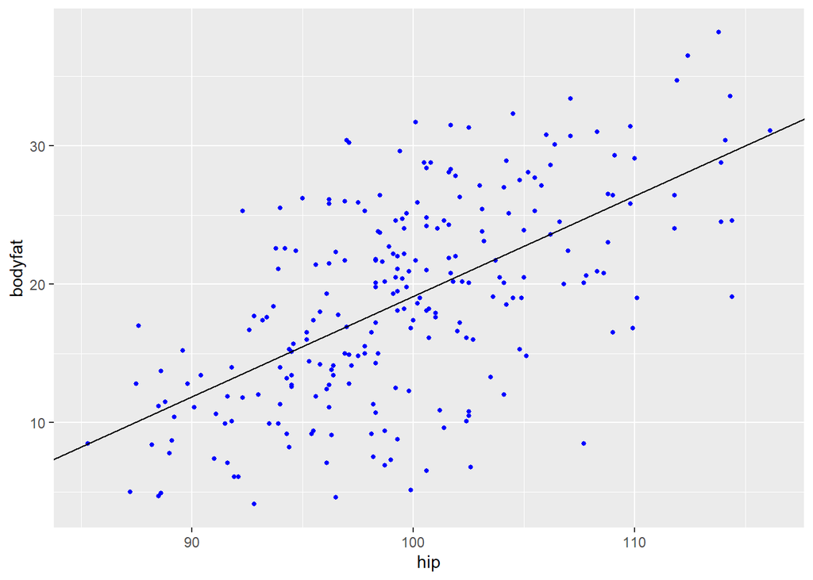

```r
alpha <- as.numeric(coef(linreg)[1]) # Intercept
beta <- as.numeric(coef(linreg)[2]) # Slope

ggplot(data = df_johnson, aes(x = hip, y = bodyfat)) +
  geom_point(color = "blue", size = 1) + # Scatter
  geom_abline(slope = beta, intercept = alpha) # line
```

## boxplot

Boxplot need one categorical value and a continuous value.

```r
data("tartar")
head(tartar, n=3)
```

```
##     treat index
## 1 Control  0.49
## 2 Control  1.05
## 3 Control  0.79
```

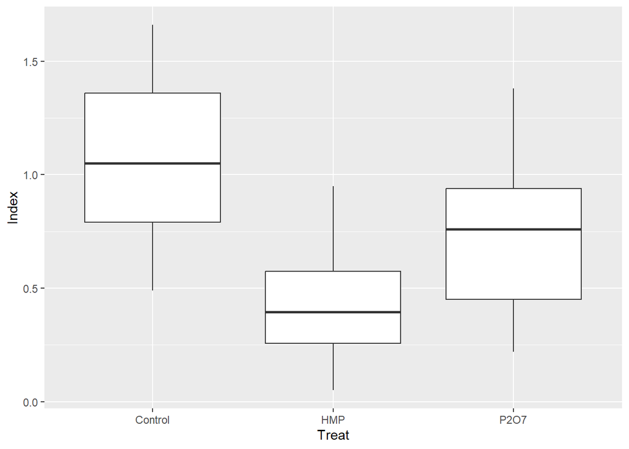

```r
ggplot(data = tartar, aes(x = treat, y = index)) +
  geom_boxplot(outliers = TRUE) +
  xlab("Treat") + ylab("Index")
```

## Histogram

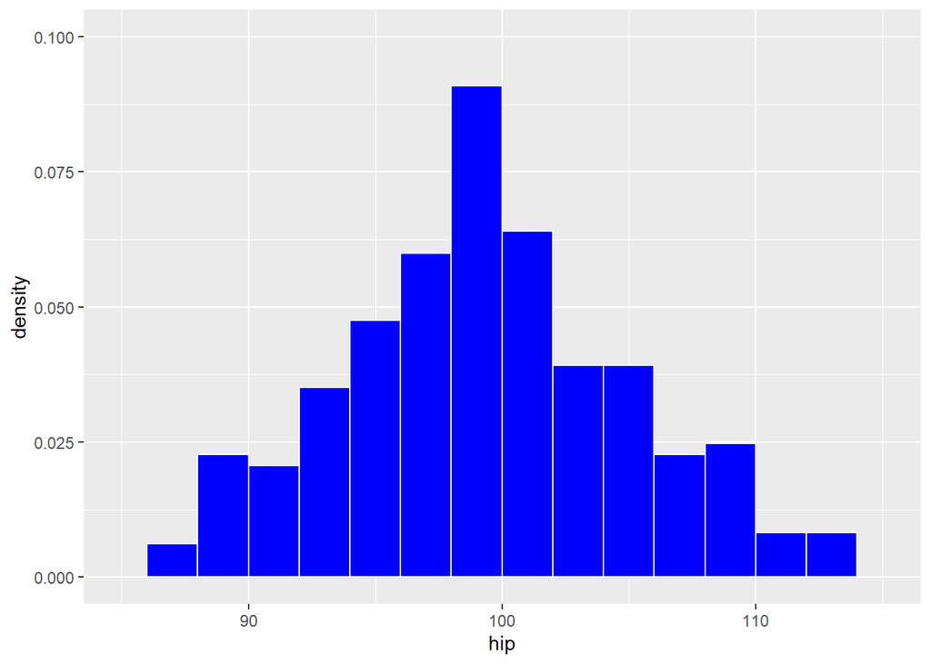

```r
ggplot(data = df_johnson, aes(x = hip)) +
  geom_histogram(
      boundary = 0,  # Start bins from 0
      binwidth = 2,  # Size of bins
      aes(y= ..density.. ), # Convert to probabilities
      color = "white", #Color outline
      fill = "blue" # Color area
  ) + xlim(85, 115) + ylim(0, 0.1) # Define x & y intervals
```

## Continuous function

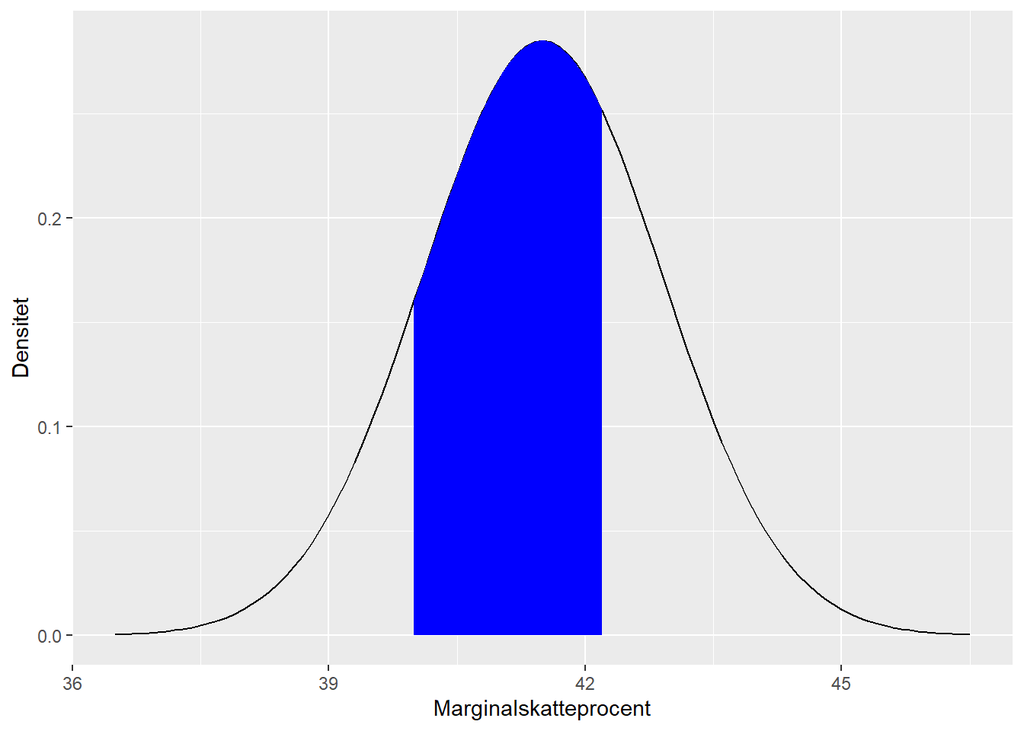

```r
data_mean = 41.5
data_sd = 1.4

ggplot(data.frame(x = c(data_mean - 5, data_mean + 5)), aes(x)) +
  # Line
  stat_function(fun = dnorm, # density of normal distribution
                args = list(mean = data_mean, sd = data_sd)) +
  # Coloring
  stat_function(fun = dnorm,
                args = list(mean = data_mean, sd = data_sd),
                xlim = c(40, 42.2), # Defines the interval
                geom = "area", fill = "blue" # Color the area blue
                ) +
  labs(x = "Marginalskatteprocent", y = "Densitet")
```

## QQplot

If the points lie on the identity line, it is normal distributed. If it curves below consider log transformation.

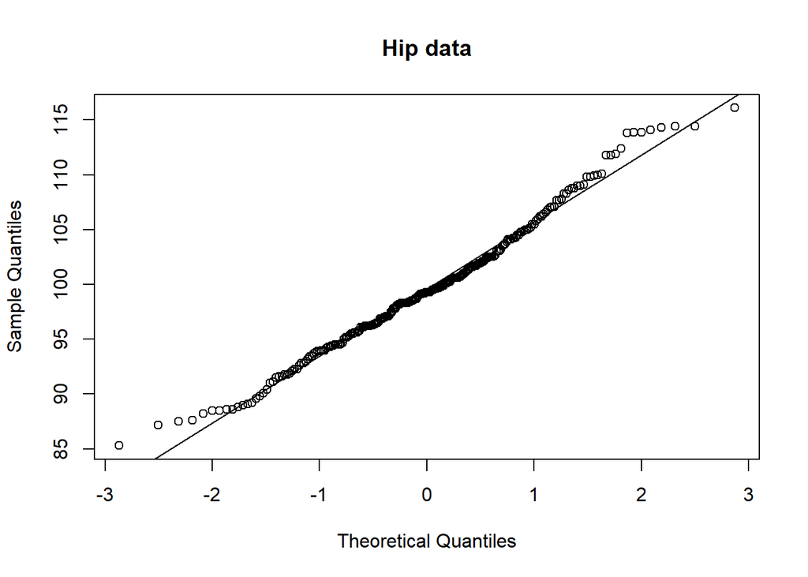

```r
qqnorm(df_johnson$hip, main = "Hip data")
abline(a = mean(df_johnson$hip), b = sd(df_johnson$hip))
```

# Model antagelser

## Linær regression

**Data:**  
Par $(x_1, y_1), ..., (x_n, y_n)$ bestående af kvantitative kontinuerte data, både for vores responsvariabel y og den forklarende variabel x.

**Statistisk model:** Vi antager $y_1 ,..., y_n$ er uafhængihed, og at alle $y_i$ er normaltfordelt med middelværdi $\mu_i = \alpha + \beta x$ (ret linje) med spredning $\sigma$

**De ukendte populationsparametre** Skæringen $\alpha$, hældningen $\beta$ og spredningen $\sigma$ er alle ukendte parametre, som vi kan estimere

# Eksempler på spørgsmål (Måske)

## Konfidens intervaller for gennemsnit

Data: Stikprøve af hip-målinger er kvatitative og kontinuerte.

middelværdi og spredning er ukendte i hele populationen.

Ud fra stikprøven vil vi udregne et estimat for middelværdi og spredning

```r
mean(df_johnson$hip)
```

```
## [1] 99.60988
```

```r
sd(df_johnson$hip)
```

```
## [1] 6.110077
```

Estimat for spredningen af gennemsnit (4.3)

```r
length(df_johnson$hip)
```

```
## [1] 243
```

```r
sd(df_johnson$hip / sqrt(length(df_johnson$hip))) #
```

```
## [1] 0.3919616
```

Beregning af t-fraktil med frihedsgrader n-1

```r
qt(0.975, df = length(df_johnson$hip) - 1)
```

```
## [1] 1.969815
```

Beregning af interval

```r
mean(df_johnson$hip) + c(-1, 1) *
  qt(0.975, df = length(df_johnson$hip) - 1) *
  sd(df_johnson$hip / sqrt(length(df_johnson$hip)))
```

```
## [1]  98.83778 100.38197
```

På baggrund af stikprøven fås et 95% konfidensinterval på (98.83, 100.38). Vi vurdere altså at intervallet med 95% sandsylighed vil indenholde det sande gennemsnit for hele populationen.

Alternativ metode:

```r
### Vha. t.test
t.test(df_johnson$hip)
```

```
##
##  One Sample t-test
##
## data:  df_johnson$hip
## t = 254.13, df = 242, p-value < 2.2e-16
## alternative hypothesis: true mean is not equal to 0
## 95 percent confidence interval:
##   98.83778 100.38197
## sample estimates:
## mean of x
##  99.60988
```

```r
### Vha. lm
model <- lm(hip ~ 1, data=df_johnson)
summary(model)
```

```
##
## Call:
## lm(formula = hip ~ 1, data = df_johnson)
##
## Residuals:
##      Min       1Q   Median       3Q      Max
## -14.3099  -4.0099  -0.3099   3.4901  16.4901
##
## Coefficients:
##             Estimate Std. Error t value Pr(>|t|)
## (Intercept)   99.610      0.392   254.1   <2e-16 ***
## ---
## Signif. codes:  0 '***' 0.001 '**' 0.01 '*' 0.05 '.' 0.1 ' ' 1
##
## Residual standard error: 6.11 on 242 degrees of freedom
```

```r
confint(model)
```

```
##                2.5 %  97.5 %
## (Intercept) 98.83778 100.382
```

## Er data normalt fordelt?

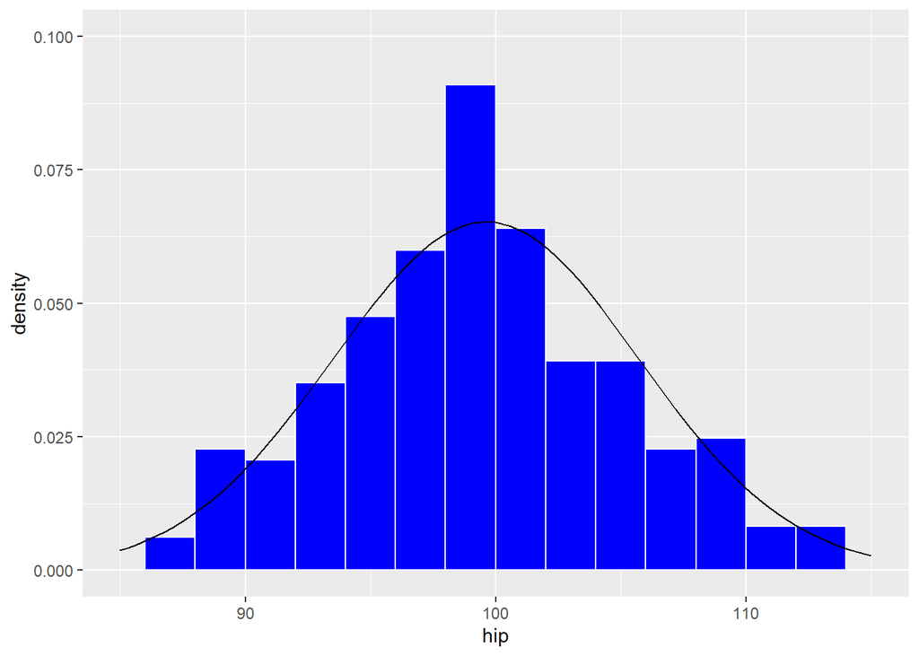

```r
ggplot(data = df_johnson, aes(x = hip)) +
  geom_histogram(
      boundary = 0,  # Start bins from 0
      binwidth = 2,  # Size of bins
      aes(y= ..density.. ), # Convert to probabilities
      color = "white", #Color outline
      fill = "blue" # Color area
  ) + xlim(85, 115) + ylim(0, 0.1) + # Define x & y intervals
    stat_function(fun = dnorm,
                args = list(mean = mean(df_johnson$hip), sd = sd(df_johnson$hip)),
                )
```

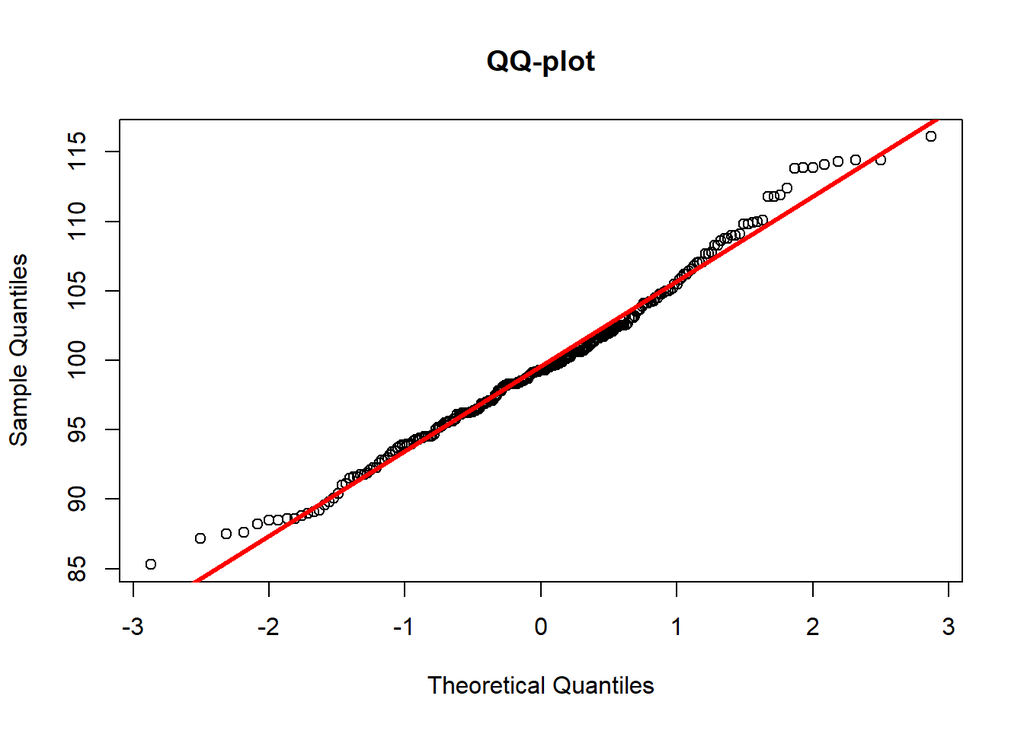

```r
qqnorm(df_johnson$hip, main="QQ-plot")
abline(mean(df_johnson$hip), sd(df_johnson$hip), lwd = 3, col = "red")
```

Vi ser ikke nogen markant systematisk afvigelse mellem punkterne og identites linjen i QQ-plottet. Datapunkterne ligger altså nogenlunde i de kvartiler, som vi forventer ved en normal fordeling. Vi konkludere at data er normaltfordelt.